# Assignment3_Group7

Rona Hu and Saujanya Acharya

October 2023

# 1 Assignment 3

```r
# Load Required Libraries
library(xml2)
library(rvest)
library(tidyverse)
library(dplyr)
library(ggplot2)
library(tidytext)
```

## 1.1 Web Scraping

In this assignment, your task is to scrape some information from Wikipedia. We start with the following page about Grand Boulevard, a Chicago Community Area.

https://en.wikipedia.org/wiki/Grand_Boulevard,_Chicago

The ultimate goal is to gather the table “Historical population” and convert it to a data.frame.

As a first step, read in the html page as an R object. Extract the tables from this object (using the rvest package) and save the result as a new object. Follow the instructions if there is an error. Use str() on this new object – it should be a list. Try to find the position of the “Historical population” in this list since we need it in the next step.

Extract the “Historical population” table from the list and save it as another object. You can use subsetting via [[…]] to extract pieces from a list. Print the result.

You will see that the table needs some additional formatting. We only want rows and columns with actual values (I called the table object pop).

#### 1.1.0.1 Scraping the “Historical Population” Table

*We need to change the code a bit from the assignment instructions* *to solve the problem we encountered in## Expanding to More Pages*

```r
# Parse Wikipedia Page
wiki_url <- read_html("https://en.wikipedia.org/wiki/Grand_Boulevard,_Chicago")

# Extract tables from page
HP_table <- wiki_url %>%
  html_nodes("table") %>%
   html_table()

HP_table_pop <- HP_table[[2]]

# Check structure of tables
str(HP_table_pop)
```

```
## tibble [11 × 4] (S3: tbl_df/tbl/data.frame)
##  $ Census                                                                                                                                                                                                : chr [1:11] "1930" "1940" "1950" "1960" ...
##  $ Pop.                                                                                                                                                                                                  : chr [1:11] "87,005" "103,256" "114,557" "80,036" ...
##  $ .mw-parser-output .sr-only{border:0;clip:rect(0,0,0,0);clip-path:polygon(0px 0px,0px 0px,0px 0px);height:1px;margin:-1px;overflow:hidden;padding:0;position:absolute;width:1px;white-space:nowrap}Note: chr [1:11] "" "" "" "" ...
##  $ %±                                                                                                                                                                                                    : chr [1:11] "—" "18.7%" "10.9%" "−30.1%" ...
```

```r
# We only want rows and columns with actual values.
pop <- HP_table_pop[1:10, -3]
pop
```

```
## # A tibble: 10 × 3
##    Census Pop.    `%±`
##    <chr>  <chr>   <chr>
##  1 1930   87,005  —
##  2 1940   103,256 18.7%
##  3 1950   114,557 10.9%
##  4 1960   80,036  −30.1%
##  5 1970   80,166  0.2%
##  6 1980   53,741  −33.0%
##  7 1990   35,897  −33.2%
##  8 2000   28,006  −22.0%
##  9 2010   21,929  −21.7%
## 10 2020   24,589  12.1%
```

## 1.2 Expanding to More Pages

That’s it for this page. However, we may want to repeat this process for other community areas. The Wikipedia page https://en.wikipedia.org/wiki/Grand_Boulevard,_Chicago has a section on “Places adjacent to Grand Boulevard, Chicago” at the bottom. Can you find the corresponding table in the list of tables that you created earlier? Extract this table as a new object.

Then, grab the community areas east of Grand Boulevard and save them as a character vector. Print the result.

We want to use this list to create a loop that extracts the population tables from the Wikipedia pages of these places. To make this work and build valid urls, we need to replace empty spaces in the character vector with underscores. This can be done with gsub(), or by hand. The resulting vector should look like this: “Oakland,_Chicago” “Kenwood,_Chicago” “Hyde_Park,_Chicago”

To prepare the loop, we also want to copy our pop table and rename it as pops. In the loop, we append this table by adding columns from the other community areas.

Build a small loop to test whether you can build valid urls using the vector of places and pasting each element of it after https://en.wikipedia.org/wiki/ in a for loop. Calling url shows the last url of this loop, which should be https://en.wikipedia.org/wiki/Hyde_Park,_Chicago.

Finally, extend the loop and add the code that is needed to grab the population tables from each page. Add columns to the original table pops using cbind().

```r
# Find the "Places adjacent to Grand Boulevard, Chicago" table
adjacent_table <- HP_table[[4]]
adjacent_table <- adjacent_table[,3]

# Check the structure of the adjacent_table
str(adjacent_table)
```

```
## tibble [5 × 1] (S3: tbl_df/tbl/data.frame)
##  $ X3: chr [1:5] "Oakland, Chicago" "" "Kenwood, Chicago" "" ...
```

```r
# Create a data frame with a single column
data_dir <- data.frame(Adjacent = unlist(adjacent_table))
data_dir
```

```
##               Adjacent
## X31   Oakland, Chicago
## X32
## X33   Kenwood, Chicago
## X34
## X35 Hyde Park, Chicago
```

```r
# Remove any empty columns
data_dir <- data_dir[, sapply(data_dir, function(x) any(nzchar(x)))]

data_dir_df <- data.frame(places = data_dir) %>%
  filter(places != "") %>%
  mutate(places = gsub(" ", "_", places))

# data_dir<- gsub(" ", "_", data_dir)

pops <- pop
colnames(pops) <- paste0("Grand Boulevard_",colnames(pop))

places_east <- data_dir_df$places

for(i in places_east) {

  wiki_url <- read_html(paste0("https://en.wikipedia.org/wiki/",i))

  HP_table <- wiki_url %>%
    html_nodes("table") %>%
    html_table()

  HP_table_pop <- HP_table[[2]]
  pop <- HP_table_pop[1:10, -3]

  nom <- gsub(",_Chicago", "", i)

  colnames(pop) <- paste0(nom, "_", colnames(pop))

  pops <- cbind(pops, pop[,-1])  # Add columns to the original table pops using cbind()
}

# Print pops to check the columns are added.
pops
```

```
##    Grand Boulevard_Census Grand Boulevard_Pop. Grand Boulevard_%± Oakland_Pop.
## 1                    1930               87,005                  —       14,962
## 2                    1940              103,256              18.7%       14,500
## 3                    1950              114,557              10.9%       24,464
## 4                    1960               80,036             −30.1%       24,378
## 5                    1970               80,166               0.2%       18,291
## 6                    1980               53,741             −33.0%       16,748
## 7                    1990               35,897             −33.2%        8,197
## 8                    2000               28,006             −22.0%        6,110
## 9                    2010               21,929             −21.7%        5,918
## 10                   2020               24,589              12.1%        6,799
##    Oakland_%± Kenwood_Pop. Kenwood_%± Hyde_Park_Pop. Hyde_Park_%±
## 1           —       26,942          —         48,017            —
## 2       −3.1%       29,611       9.9%         50,550         5.3%
## 3       68.7%       35,705      20.6%         55,206         9.2%
## 4       −0.4%       41,533      16.3%         45,577       −17.4%
## 5      −25.0%       26,890     −35.3%         33,531       −26.4%
## 6       −8.4%       21,974     −18.3%         31,198        −7.0%
## 7      −51.1%       18,178     −17.3%         28,630        −8.2%
## 8      −25.5%       18,363       1.0%         29,920         4.5%
## 9       −3.1%       17,841      −2.8%         25,681       −14.2%
## 10      14.9%       19,116       7.1%         29,456        14.7%
```

```r
# Print places_east to check the resulting vector.
# It should look like this: "Oakland,_Chicago" "Kenwood,_Chicago" "Hyde_Park,_Chicago"
places_east
```

```
## [1] "Oakland,_Chicago"   "Kenwood,_Chicago"   "Hyde_Park,_Chicago"
```

```r
# Print constructed URLs and check the output.
# The last url of this loop, which should be https://en.wikipedia.org/wiki/Hyde_Park,_Chicago.

for(place in places_east) {
  url <- paste0("https://en.wikipedia.org/wiki/", place)
  print(url)
}
```

```
## [1] "https://en.wikipedia.org/wiki/Oakland,_Chicago"
## [1] "https://en.wikipedia.org/wiki/Kenwood,_Chicago"
## [1] "https://en.wikipedia.org/wiki/Hyde_Park,_Chicago"
```

## 1.3 Scraping and Analyzing Text Data

Suppose we wanted to take the actual text from the Wikipedia pages instead of just the information in the table. Our goal in this section is to extract the text from the body of the pages, then do some basic text cleaning and analysis.

First, scrape just the text without any of the information in the margins or headers. For example, for “Grand Boulevard”, the text should start with, “Grand Boulevard on the South Side of Chicago, Illinois, is one of the …”. Make sure all of the text is in one block by using something like the code below (I called my object description).

```r
# description <- description %>% paste(collapse = ' ')

# Scrape the text from the "Grand Boulevard" Wikipedia page
wiki_url <- read_html("https://en.wikipedia.org/wiki/Grand_Boulevard,_Chicago")

# Extract the text from the body of the page
description <- wiki_url %>%
  html_nodes('div#mw-content-text p') %>%
  html_text()

# Make sure all of the text is in one block
description <- description %>% paste(collapse = ' ')

# Check the beginning of the text to ensure it's correct
substring(description, 1, 100)
```

```
## [1] "\n Grand Boulevard on the South Side of Chicago, Illinois, is one of the city's Community Areas. The "
```

Using a similar loop as in the last section, grab the descriptions of the various communities areas. Make a tibble with two columns: the name of the location and the text describing the location.

Let’s clean the data using tidytext. If you have trouble with this section, see the example shown in https://www.tidytextmining.com/tidytext.html

```r
# Initialize a list to store text data from each community area
text_data <- list()

# Loop through the community areas and scrape text data
for(place in places_east) {
  url <- paste0("https://en.wikipedia.org/wiki/", place)
  wiki_url <- read_html(url)
  description <- wiki_url %>%
    html_nodes('div#mw-content-text p') %>%
    html_text()
  description <- paste(description, collapse = ' ')
  text_data[[place]] <- description
}

# Check the text data for one of the community areas
substring(text_data[["Oakland,_Chicago"]], 1, 100)
```

```
## [1] "Oakland, located on the South Side of Chicago, Illinois, USA, is one of 77 officially designated Chi"
```

```r
# Initialize a tibble to store the location names and their descriptions
location_descriptions <- tibble(location = character(), description = character())

# Add Grand Boulevard's description
# location_descriptions <- add_row(location_descriptions, location = "Grand Boulevard", description = description)

# Loop through the other community areas to grab descriptions
for (place in places_east) {

  # Construct the Wikipedia URL
  url <- paste0("https://en.wikipedia.org/wiki/", place)

  # Read the HTML content of the Wikipedia page
  wiki_url <- read_html(url)

  # Extract the text from the body of the page
  description <- wiki_url %>%
    html_nodes('div#mw-content-text p') %>%
    html_text() %>%
    paste(collapse = ' ')

  # Add the location and its description to the tibble
  location_name <- gsub("_", " ", gsub(",_Chicago", "", place))

  location_descriptions <- add_row(location_descriptions, location = location_name, description = description)
}

# View the first few rows of the scraped data
head(location_descriptions)
```

```
## # A tibble: 3 × 2
##   location  description
##   <chr>     <chr>
## 1 Oakland   "Oakland, located on the South Side of Chicago, Illinois, USA, is o…
## 2 Kenwood   "\n Kenwood, one of Chicago's 77 community areas, is on the shore o…
## 3 Hyde Park "\n Hyde Park is the 41st of the 77 community areas of Chicago. It …
```

Create tokens using unnest_tokens. Make sure the data is in one-token-per-row format. Remove any stop words within the data. What are the most common words used overall?

Plot the most common words within each location. What are some of the similarities between the locations? What are some of the differences?

```r
# Tokenizing the text data
tokens <- location_descriptions %>%
  unnest_tokens(word, description)

# Removing stop words
tokens_cleaned <- tokens %>%
  anti_join(stop_words)

# Counting the most common words overall
word_count <- tokens_cleaned %>%
  count(word, sort = TRUE)

# Viewing the most common words
print(word_count)
```

```
## # A tibble: 1,051 × 2
##    word          n
##    <chr>     <int>
##  1 park         88
##  2 hyde         75
##  3 chicago      50
##  4 street       40
##  5 kenwood      38
##  6 oakland      25
##  7 community    23
##  8 lake         20
##  9 located      19
## 10 south        19
## # ℹ 1,041 more rows
```

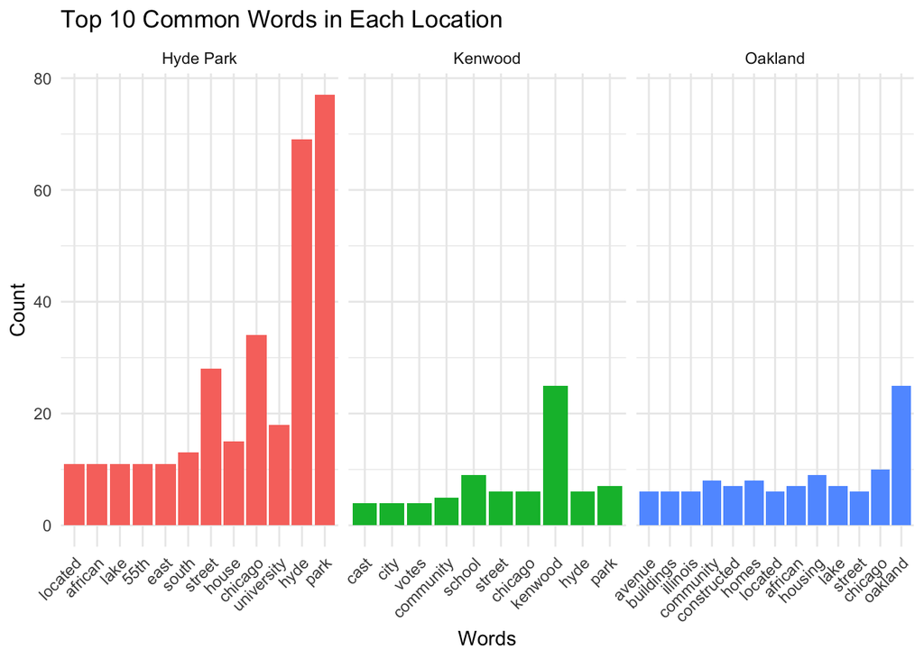

```r
# Plotting the most common words within each location
tokens_cleaned %>%
  group_by(location) %>%
  count(word, sort = TRUE) %>%
  top_n(10, n) %>%
  ggplot(aes(x = reorder(word, n), y = n, fill = location)) +
  geom_col(show.legend = FALSE) +
  facet_wrap(~location, scales = "free_x") +
  labs(title = "Top 10 Common Words in Each Location",
       x = "Words",
       y = "Count") +
  theme_minimal() +
  theme(axis.text.x = element_text(angle = 45, hjust = 1))
```

In this plot, we can observe the top 10 most common words used in the Wikipedia descriptions of the three east places. Here are the similarities and the differences between the locations:

*Similarities*:

- Common Descriptive Words: Some words may be commonly used across multiple places, possibly reflecting shared characteristics or attributes.
- Prevalent Themes: Certain themes or topics might recur in the descriptions of different places, indicating shared history, culture, or geographical features.
- Location-Related Terms: Words that are related to the location, such as “street,” “located,” or “community,” might frequently appear across multiple descriptions.
- Recurrence of the Names: Each place’s own name is likely to appear frequently in its respective description.

*Differences*:

- Unique Themes: Some words or themes might be unique to specific places, like distinctive attributes or historical events associated with those places.
- Variation in Descriptive Focus: Different places might have variations in the aspects of community life, history, or geography that are emphasized in their descriptions.